# Microbial compositional analysis in response to a inulin treatment

Roger Calvas

2025-05-02

# Goals

In this file, we will perform compositional analysis of our scaled/noramlized/rarefied microbial dataset!

1. Load in scaled/normalized phyloseq object.
2. Calculate the relative abundances of taxonomic groups at various levels: A. Phylum B. Genus C. ASV
3. Plot them, and narrow in on specific taxnomic group of interest
1. We will need the `scaled_physeq.RData`, which includes a rooted tree that we created in `analysis/06_Ordination/scaled_physeq.RData`.

## Outputs

# Compositional Data

Microbial abundance data—like 16S rRNA gene or metagenomics data—are typically **compositional:** they represent relative abundances constrained to a constant total (*e.g.,* percent or proportions). This introduces spurious correlations and other issues if analyzed with traditional statistics. This is a very important limitation to microbial data!

INTERPRETATION #1: What are the limitations of interpreting microbial abundance from relative (aka. compositional) rather than absolute counts?

## Load Packages

```r
# Load in the packages
pacman::p_load(tidyverse, devtools, DT, phyloseq, patchwork, ggpubr,
               install = FALSE)

# load colors
source("code/colors.R")
```

## 1. Load in Scaled Phyloseq object

```r
load("data/06_Ordination/scaled_physeq.RData")

# Look at the data
scaled_physeq
```

```
## phyloseq-class experiment-level object
## otu_table()   OTU Table:         [ 1976 taxa and 161 samples ]
## sample_data() Sample Data:       [ 161 samples by 54 sample variables ]
## tax_table()   Taxonomy Table:    [ 1976 taxa by 9 taxonomic ranks ]
## phy_tree()    Phylogenetic Tree: [ 1976 tips and 1975 internal nodes ]
```

```r
# Intuition check - scaled at 1,942
min(sample_sums(scaled_physeq))
```

```
## [1] 7191
```

```r
range(sample_sums(scaled_physeq))
```

```
## [1] 7191 7229
```

# Taxonomic analysis

### Phylum

```r
# Create a phylum level dataframe
phylum_df <-
  scaled_physeq %>%
  # Agglomerate all ASV counts within a phylum
  tax_glom(taxrank = "Phylum") %>%
  # Calculate the relative abundance!
  transform_sample_counts(function(x) {x/sum(x)}) %>%
  # Create a dataframe from phyloseq object
  psmelt()



## What are the phylum abundances?
phylum_df %>%
  group_by(Phylum) %>%
  summarize(mean_PercAbund = round(mean(Abundance), digits = 4)) %>%
  arrange(-mean_PercAbund) %>%
  datatable()
```

|  | Phylum | mean_PercAbund |
| --- | --- | --- |
| 1 | Bacteroidota | 0.528 |
| 2 | Bacillota | 0.3833 |
| 3 | Pseudomonadota | 0.0401 |
| 4 | Actinomycetota | 0.0377 |
| 5 | Verrucomicrobiota | 0.0054 |
| 6 | Thermodesulfobacteriota | 0.004 |
| 7 | Cyanobacteriota | 0.0013 |
| 8 | Fusobacteriota | 0.0002 |
| 9 | Acidobacteriota | 0 |
| 10 | Campylobacterota | 0 |

[output cut: 9 more lines]

```r
# Make a list of phyla the top phyla
top10_phyla <-
  phylum_df %>%
  group_by(Phylum) %>%
  summarize(mean_PercAbund = mean(Abundance)) %>%
  arrange(-mean_PercAbund) %>%
  head(n = 10) %>%
  pull(Phylum)
```

INTERPRETATION #2: Which phyla in your dataset have the highest relative abundances? What are their abundances? We will focus on these phyla for plotting below. :)

## Stacked Bar plots

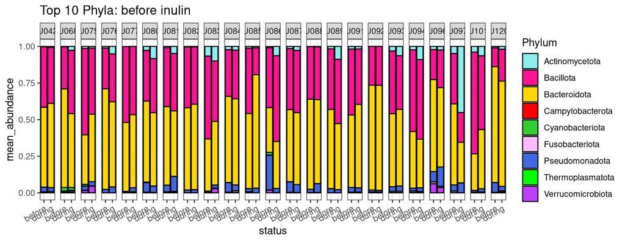

```r
# Stacked Bar Plot With All phyla
# Plot Phylum Abundances - make sure to load phylum_colors
phylum_df %>%
  dplyr::filter(Phylum %in% top10_phyla) %>%
  # Warning: It's important to have one sample per x value,
  # otherwise, it will take the sum between multiple samples
  group_by(host_subject_id, status, Phylum) %>%
  summarise(mean_abundance = mean(Abundance), .groups = "drop") %>%
  ggplot(aes(x = status, y = mean_abundance, fill = Phylum)) +
  geom_bar(stat = "identity", color = "black") +
   facet_grid(.~host_subject_id) +
  labs(title = "Top 10 Phyla: before inulin") +
  scale_fill_manual(values = phylum_colors) +
  theme_bw() +
  theme(axis.text.x = element_text(angle = 30, hjust = 1, vjust = 1))
```

## Faceted Bar plot

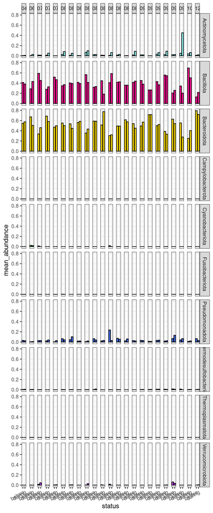

```r
phylum_df %>%
  dplyr::filter(Phylum %in% top10_phyla) %>%
  # Individual sample comparison of surface waters, whole fraction
  # This will allow us to look at individual samples!
  # Note that whenever plotting stacked bar plots, you should always look at Individual samples!
  group_by(host_subject_id, status, Phylum) %>%
  summarise(mean_abundance = mean(Abundance), .groups = "drop") %>%
  ggplot(aes(x = status, y = mean_abundance, fill = Phylum)) +
   facet_grid(Phylum~host_subject_id) +
  # add the stacked bar
  geom_bar(stat = "identity", color = "black") +
  # change the colors to be our selected colors
  scale_fill_manual(values = phylum_colors) +
  theme_bw() +
  theme(legend.position = "none",
        axis.text.x = element_text(angle = 30, hjust = 1, vjust = 1))
```

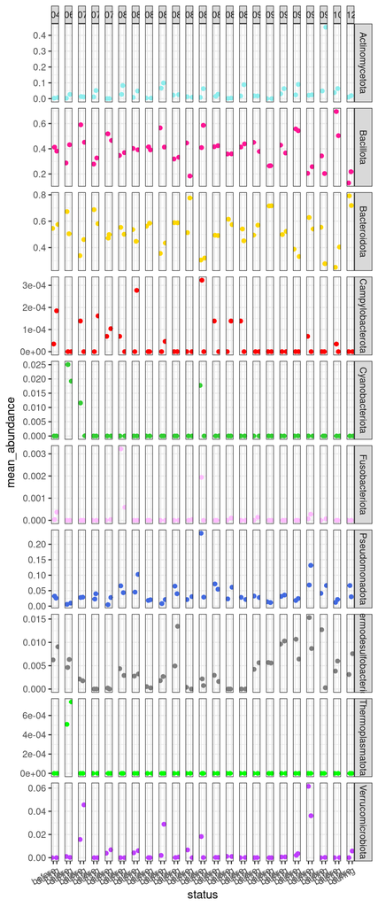

```r
### Or combined together:
phylum_df %>%
  dplyr::filter(Phylum %in% top10_phyla)  %>%
  group_by(host_subject_id, status, Phylum) %>%
  summarise(mean_abundance = mean(Abundance), .groups = "drop") %>%
  ggplot(aes(x = status, y = mean_abundance, fill = Phylum, color = Phylum)) +
  facet_grid(Phylum~host_subject_id, scale = "free") +
  # add the stacked bar
  geom_jitter() +
  geom_boxplot(outlier.shape = NA, alpha = 0.5) +
  # change the colors to be our selected colors
  scale_fill_manual(values = phylum_colors) +
  scale_color_manual(values = phylum_colors) +
  theme_bw() +
  theme(legend.position = "none",
        axis.text.x = element_text(angle = 30, hjust = 1, vjust = 1))
```

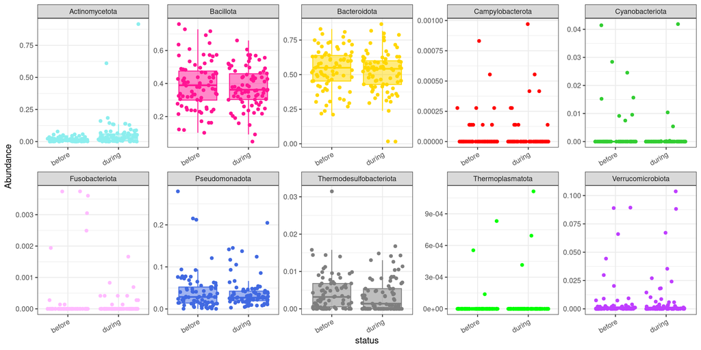

```r
### Or combined together:
phylum_df %>%
  dplyr::filter(Phylum %in% top10_phyla) %>%
  ggplot(aes(x = status, y = Abundance, fill = Phylum, color = Phylum)) +
  facet_wrap(Phylum~., scales = "free", nrow = 2) +
  # add the stacked bar
  geom_jitter() +
  geom_boxplot(outlier.shape = NA, alpha = 0.5) +
  # change the colors to be our selected colors
  scale_fill_manual(values = phylum_colors) +
  scale_color_manual(values = phylum_colors) +
  theme_bw() +
  theme(legend.position = "none",
        axis.text.x = element_text(angle = 30, hjust = 1, vjust = 1))
```

INTERPRETATION #3: Make the above dotplot and boxplot for your sample types and your most abundant phyla. What initial conclusions can you draw regarding the sampled microbial communities as it relates to your scientific question?

### A1. Actinomycetota

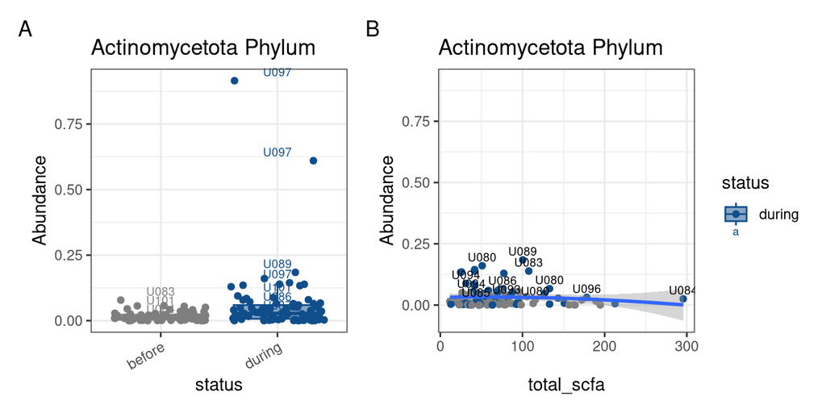

```r
# Narrow in on a specific group
# Actinomycetota
actino_phylum_status <-
  phylum_df %>%
  dplyr::filter(Phylum == "Actinomycetota") %>%
  # build the plot
  ggplot(aes(x = status, y = Abundance,
             fill = status, color = status)) +
  geom_boxplot(alpha = 0.5, outlier.shape = NA) + # outliers not plotted here in boxplot
  geom_jitter() +
  theme_bw() +
  labs(title = "Actinomycetota Phylum") +
  scale_color_manual(values = status_colors) +
  scale_fill_manual(values = status_colors) +
    theme(axis.text.x = element_text(angle = 30, hjust = 1, vjust = 1),
          legend.position = "right") +
    geom_text(aes(label = host_subject_id),
            vjust = -0.5, size = 2.5, check_overlap = TRUE)
# Statistically: Kruskall-Wallis followed by a Tukey's Posthoc test
# These are non-parametric (non-normal) stat tests


# CONTINUOUS
actino_phylum_total_scfa <-
  phylum_df %>%
  dplyr::filter(Phylum == "Actinomycetota") %>%
  ggplot(aes(x = total_scfa, y = Abundance)) +
  geom_point(aes(color = status)) +
  theme_bw() +
  geom_smooth(method = "lm",  formula = y ~ poly(x, 2)) +
  labs(title = "Actinomycetota Phylum") +
  scale_color_manual(values = status_colors) +
  theme(legend.position = "none") +
  geom_text(aes(label = host_subject_id),
            vjust = -0.5, size = 2.5, check_overlap = TRUE)

# Collect both of the plots together into one
actino_phylum_status + actino_phylum_total_scfa +
  plot_layout(guides = "collect") +
  plot_annotation(tag_levels = "A")
```

### A2. Bacillota

[figure not shown]

```r
# Narrow in on a specific group
# Bacillota
bacillota_phylum_status <-
  phylum_df %>%
  dplyr::filter(Phylum == "Bacillota") %>%
  # build the plot
  ggplot(aes(x = status, y = Abundance,
             fill = status, color = status)) +
  geom_boxplot(alpha = 0.5, outlier.shape = NA) + # outliers not plotted here in boxplot
  geom_jitter() +
  theme_bw() +
  labs(title = "Actinomycetota Phylum") +
  scale_color_manual(values = status_colors) +
  scale_fill_manual(values = status_colors) +
    theme(axis.text.x = element_text(angle = 30, hjust = 1, vjust = 1),
          legend.position = "right") +
    geom_text(aes(label = host_subject_id),
            vjust = -0.5, size = 2.5, check_overlap = TRUE)
# Statistically: Kruskall-Wallis followed by a Tukey's Posthoc test
# These are non-parametric (non-normal) stat tests


# CONTINUOUS
bacillota_phylum_total_scfa <-
  phylum_df %>%
  dplyr::filter(Phylum == "Bacillota") %>%
  ggplot(aes(x = total_scfa, y = Abundance)) +
  geom_point(aes(color = status)) +
  theme_bw() +
  geom_smooth(method = "lm",  formula = y ~ poly(x, 2)) +
  labs(title = "Actinomycetota Phylum") +
  scale_color_manual(values = status_colors) +
  theme(legend.position = "none") +
  geom_text(aes(label = host_subject_id),
            vjust = -0.5, size = 2.5, check_overlap = TRUE)

# Collect both of the plots together into one
bacillota_phylum_status + bacillota_phylum_total_scfa +
  plot_layout(guides = "collect") +
  plot_annotation(tag_levels = "A")
```

## B. Genus

Let’s first calculate the genus data frame.

```r
# Calculate the Family relative abundance
# Note: The read depth MUST be normalized in some way: scale_reads
genus_df <-
  scaled_physeq %>%
  # agglomerate at the phylum level
  tax_glom(taxrank = "Genus") %>%
  # Transform counts to relative abundance
  transform_sample_counts(function (x) {x/sum(x)}) %>%
  # Melt to a long format
  psmelt()
```

### B1. Actinomycetota genus

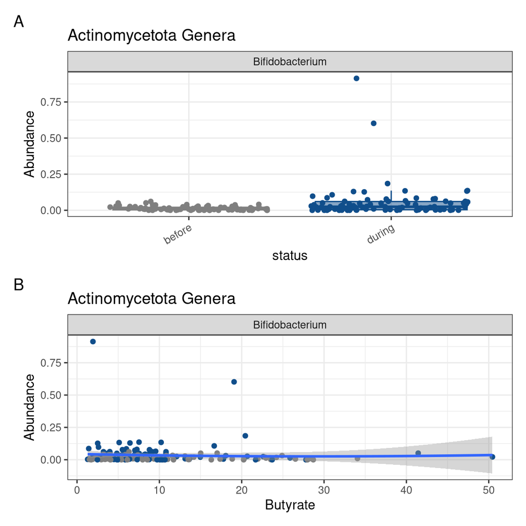

```r
# Actinobacteriota
# Plot genus
actino_genus_status <-
  genus_df %>%
  dplyr::filter(Phylum == "Actinomycetota") %>%
   dplyr::filter(Genus %in% "Bifidobacterium") %>%
  # At first, plot all of the genera and then subset the ones that have intersting trends
  # build the plot
  ggplot(aes(x = status, y = Abundance,
             fill = status, color = status)) +
  facet_wrap(.~Genus, scales = "free_y", nrow = 1) +
  geom_boxplot(alpha = 0.5, outlier.shape = NA) + # outliers not plotted here in boxplot
  geom_jitter() +
  theme_bw() +
  labs(title = "Actinomycetota Genera") +
  scale_color_manual(values = status_colors) +
  scale_fill_manual(values = status_colors) +
  theme(axis.text.x = element_text(angle = 30, hjust = 1, vjust = 1),
        legend.position = "none")

# Plot genus: Continuous
actino_genus_butyrate <-
  genus_df %>%
  dplyr::filter(Phylum == "Actinomycetota") %>%
  dplyr::filter(Genus %in% "Bifidobacterium") %>%
  # build the plot
  ggplot(aes(x = Butyrate, y = Abundance)) +
  facet_wrap(.~Genus, scales = "free_y", nrow = 1) +
  geom_point(aes(color = status)) +  theme_bw() +
  geom_smooth(method = "lm",  formula = y ~ poly(x, 2)) +
  labs(title = "Actinomycetota Genera") +
  scale_color_manual(values = status_colors) +
  theme(legend.position = "none")

# Collect the Actinomycetota Plots
actino_genus_status / actino_genus_butyrate +
  plot_layout(guides = "collect") +
  plot_annotation(tag_levels = "A")
```

### B2. Bacillota genus

[figure not shown]

```r
bacillota_family_status <-
  genus_df %>%
  dplyr::filter(Phylum == "Bacillota") %>%
   dplyr::filter(Family %in% "Ruminococcaceae") %>%
  ggplot(aes(x = status, y = Abundance,
             fill = status, color = status)) +
  facet_wrap(.~Genus, scales = "free_y", nrow = 1) +
  geom_boxplot(alpha = 0.5, outlier.shape = NA) + # outliers not plotted here in boxplot
  geom_jitter() +
  theme_bw() +
  labs(title = "Bacillota Genera") +
  scale_color_manual(values = status_colors) +
  scale_fill_manual(values = status_colors) +
  theme(axis.text.x = element_text(angle = 30, hjust = 1, vjust = 1),
        legend.position = "none")

# Plot genus: Continuous
bacillota_family_butyrate <-
  genus_df %>%
  dplyr::filter(Phylum == "Bacillota") %>%
   dplyr::filter(Family %in% "Ruminococcaceae") %>%
  # build the plot
  ggplot(aes(x = Butyrate, y = Abundance)) +
  facet_wrap(.~Genus, scales = "free_y", nrow = 1) +
  geom_point(aes(color = status)) +  theme_bw() +
  geom_smooth(method = "lm",  formula = y ~ poly(x, 2)) +
  labs(title = "Bacillota Genera") +
  scale_color_manual(values = status_colors) +
  theme(legend.position = "none")

# Collect the Bacillota Plots
bacillota_family_status / bacillota_family_butyrate +
  plot_layout(guides = "collect") +
  plot_annotation(tag_levels = "A")
```

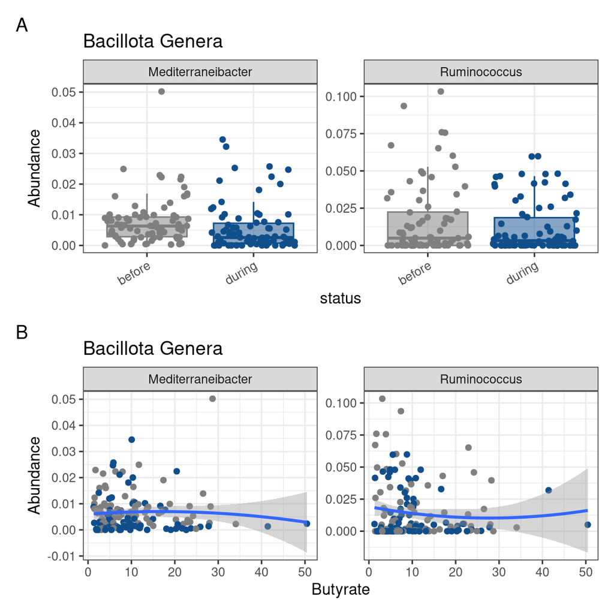

```r
# Plot genus
bacillota_genus_status <-
  genus_df %>%
  dplyr::filter(Phylum == "Bacillota") %>%
   dplyr::filter(Genus %in% c("Mediterraneibacter", "Ruminococcus")) %>%
  ggplot(aes(x = status, y = Abundance,
             fill = status, color = status)) +
  facet_wrap(.~Genus, scales = "free_y", nrow = 1) +
  geom_boxplot(alpha = 0.5, outlier.shape = NA) + # outliers not plotted here in boxplot
  geom_jitter() +
  theme_bw() +
  labs(title = "Bacillota Genera") +
  scale_color_manual(values = status_colors) +
  scale_fill_manual(values = status_colors) +
  theme(axis.text.x = element_text(angle = 30, hjust = 1, vjust = 1),
        legend.position = "none")

# Plot genus: Continuous
bacillota_genus_butyrate <-
  genus_df %>%
  dplyr::filter(Phylum == "Bacillota") %>%
   dplyr::filter(Genus %in% c("Mediterraneibacter", "Ruminococcus")) %>%
  # build the plot
  ggplot(aes(x = Butyrate, y = Abundance)) +
  facet_wrap(.~Genus, scales = "free_y", nrow = 1) +
  geom_point(aes(color = status)) +  theme_bw() +
  geom_smooth(method = "lm",  formula = y ~ poly(x, 2)) +
  labs(title = "Bacillota Genera") +
  scale_color_manual(values = status_colors) +
  theme(legend.position = "none")

# Collect the Bacillota Plots
bacillota_genus_status / bacillota_genus_butyrate +
  plot_layout(guides = "collect") +
  plot_annotation(tag_levels = "A")
```

INTERPRETATION #5: Please make some plots of mid-level taxonomic ranks (e.g. Genus, Family, Order) as it relates to your scientific question. Were there any changes in the mid-level taxonomic trends compared to the phylum-level results? What does that tell you about that taxonomic group? I found the mid levels group did not particularly help to respond my scientific question, the microbiome is quite stable and I am more interesting in seeing the degraders of inulin and butyrate producers, because of this mid-level analysis is diluted by unrelated taxa. Bifidobacterium did show a slight trend but with my subset of data a lot of the species within the Genus are not present.

## C. ASV level

```r
# Calculate the Family relative abundance
# Note: The read depth MUST be normalized in some way: scale_reads
ASV_df <-
  scaled_physeq %>%
  # Prune out ASVs that have fewer than 100 counts!
  ## LOOK AT HOW MANY ARE REMOVED! We scaled to 1,962 reads!
  prune_taxa(taxa_sums(.) >= 196, .) %>%
  # agglomerate at the phylum level
  tax_glom(taxrank = "ASV") %>%
  # Transform counts to relative abundance
  transform_sample_counts(function (x) {x/sum(x)}) %>%
  # Melt to a long format
  psmelt()
```

### C1. Actinomycetota ASVs

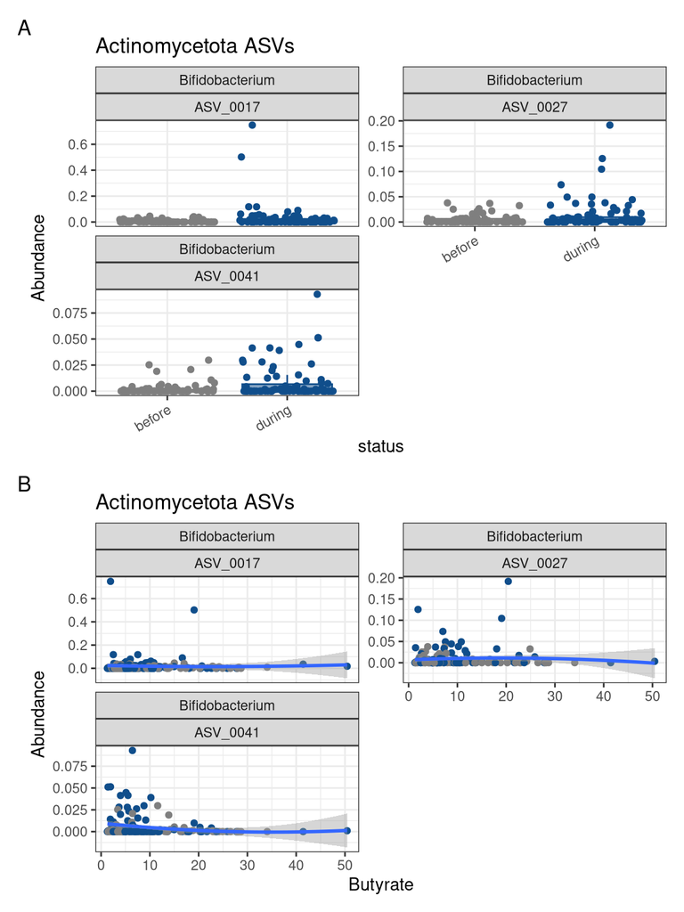

```r
# Calculate top couple of ASVs
# Make a list of phyla the top phyla
top_actino_ASVs <-
  ASV_df %>%
  dplyr::filter(Phylum == "Actinomycetota") %>%
  group_by(ASV) %>%
  summarize(mean_Abundance = mean(Abundance)) %>%
  dplyr::filter(mean_Abundance > 0.005) %>%
  pull(ASV)

# Actinobacteriota
# Plot ASVs
actino_asv_status <-
  ASV_df %>%
  dplyr::filter(ASV %in% top_actino_ASVs) %>%
  # build the plot
  ggplot(aes(x = status, y = Abundance,
             fill = status, color = status)) +
  facet_wrap(Genus~ASV, scales = "free_y", nrow = 2) +
  geom_boxplot(alpha = 0.5, outlier.shape = NA) + # outliers not plotted here in boxplot
  geom_jitter() +
  theme_bw() +
  labs(title = "Actinomycetota ASVs") +
  scale_color_manual(values = status_colors) +
  scale_fill_manual(values = status_colors) +
  theme(axis.text.x = element_text(angle = 30, hjust = 1, vjust = 1),
        legend.position = "none")

# Plot ASVs: Continuous
actino_asv_butyrate <-
  ASV_df %>%
  dplyr::filter(ASV %in% top_actino_ASVs) %>%
  # build the plot
  ggplot(aes(x = Butyrate, y = Abundance)) +
  facet_wrap(Genus~ASV, scales = "free_y", nrow = 2) +
  geom_point(aes(color = status)) +  theme_bw() +
  geom_smooth(method = "lm",  formula = y ~ poly(x, 2)) +
  labs(title = "Actinomycetota ASVs") +
  scale_color_manual(values = status_colors) +
  theme(legend.position = "none")

# Collect the Actinomycetota Plots
actino_asv_status / actino_asv_butyrate +
  plot_layout(guides = "collect") +
  plot_annotation(tag_levels = "A")
```

### C2. Bacillota ASVs

[figure not shown]

```r
# Calculate top couple of ASVs
# Make a list of phyla the top phyla
top_bacillota_ASVs <-
  ASV_df %>%
  dplyr::filter(Phylum == "Bacillota") %>%
  group_by(ASV) %>%
  summarize(mean_Abundance = mean(Abundance)) %>%
  dplyr::filter(mean_Abundance > 0.005) %>%
  pull(ASV)

# Plot ASVs: Station
bacillota_asv_status <-
  ASV_df %>%
  # Subset for more abundant ASVs
  dplyr::filter(ASV %in% top_bacillota_ASVs) %>%
  # build the plot
  ggplot(aes(x = status, y = Abundance,
             fill = status, color = status)) +
  facet_wrap(Genus~ASV, scales = "free_y", nrow = 2) +
  geom_boxplot(alpha = 0.5, outlier.shape = NA) + # outliers not plotted here in boxplot
  geom_jitter() +
  theme_bw() +
  labs(title = "bacillota ASVs > 0.05%") +
  scale_color_manual(values = status_colors) +
  scale_fill_manual(values = status_colors) +
  theme(axis.text.x = element_text(angle = 30, hjust = 1, vjust = 1),
        legend.position = "none")

# Plot ASVs: Continuous
bacillota_asv_butyrate <-
  ASV_df %>%
  dplyr::filter(ASV %in% top_bacillota_ASVs) %>%
  # build the plot
  ggplot(aes(x = Butyrate, y = Abundance)) +
  facet_wrap(Genus~ASV, scales = "free_y", nrow = 2) +
  geom_point(aes(color = status)) +  theme_bw() +
  geom_smooth(method = "lm",  formula = y ~ poly(x, 2)) +
  labs(title = "bacillota ASVs > 0.05%") +
  scale_color_manual(values = status_colors) +
  theme(legend.position = "none")

# Collect the Actinomycetota Plots
bacillota_asv_status / bacillota_asv_butyrate +
  plot_layout(guides = "collect") +
  plot_annotation(tag_levels = "A")
```

### Extra ASVS

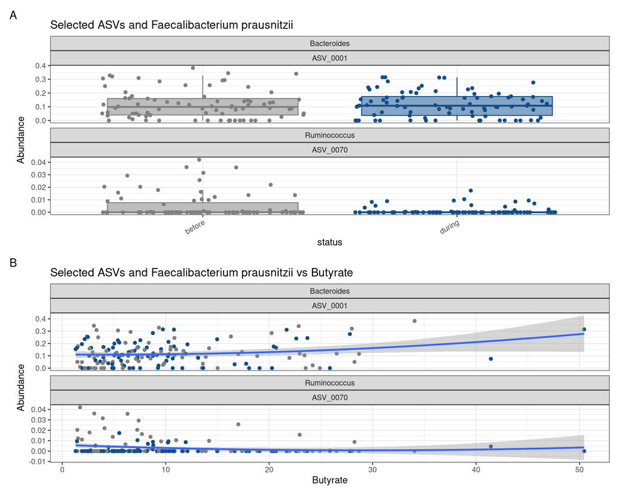

```r
target_df <-
  ASV_df %>%
  dplyr::filter(ASV %in% c("ASV_0001", "ASV_0070"))

target_asv_status <-
  target_df %>%
  ggplot(aes(x = status, y = Abundance,
             fill = status, color = status)) +
  facet_wrap(Genus~ASV, scales = "free_y", nrow = 2) +
  geom_boxplot(alpha = 0.5, outlier.shape = NA) +
  geom_jitter() +
  theme_bw() +
  labs(title = "Selected ASVs and Faecalibacterium prausnitzii") +
  scale_color_manual(values = status_colors) +
  scale_fill_manual(values = status_colors) +
  theme(axis.text.x = element_text(angle = 30, hjust = 1, vjust = 1),
        legend.position = "none")

# Plot: Abundance vs Butyrate (continuous)
target_asv_butyrate <-
  target_df %>%
  ggplot(aes(x = Butyrate, y = Abundance)) +
  facet_wrap(Genus~ASV, scales = "free_y", nrow = 2) +
  geom_point(aes(color = status)) +
  geom_smooth(method = "lm", formula = y ~ poly(x, 2)) +
  theme_bw() +
  labs(title = "Selected ASVs and Faecalibacterium prausnitzii vs Butyrate") +
  scale_color_manual(values = status_colors) +
  theme(legend.position = "none")

# Combine plots
target_asv_status / target_asv_butyrate +
  plot_layout(guides = "collect") +
  plot_annotation(tag_levels = "A")
```

### prausnitzii ASVs

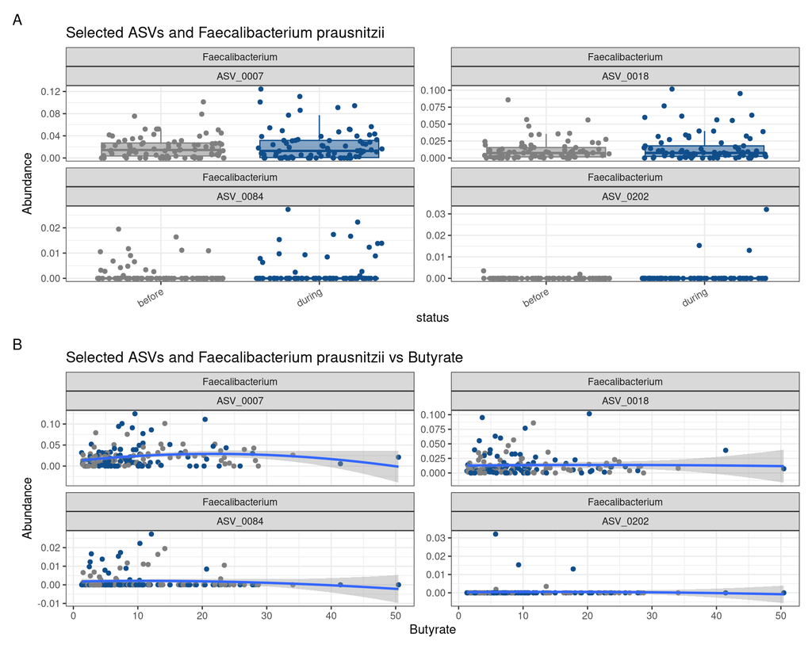

```r
prausnitzii_df <-
  ASV_df %>%
  dplyr::filter(ASV %in% c("ASV_0084", "ASV_0202", "ASV_0018", "ASV_0007"))

prausnitzii_asv_status <-
  prausnitzii_df %>%
  ggplot(aes(x = status, y = Abundance,
             fill = status, color = status)) +
  facet_wrap(Genus~ASV, scales = "free_y", nrow = 2) +
  geom_boxplot(alpha = 0.5, outlier.shape = NA) +
  geom_jitter() +
  theme_bw() +
  labs(title = "Selected ASVs and Faecalibacterium prausnitzii") +
  scale_color_manual(values = status_colors) +
  scale_fill_manual(values = status_colors) +
  theme(axis.text.x = element_text(angle = 30, hjust = 1, vjust = 1),
        legend.position = "none")

# Plot: Abundance vs Butyrate (continuous)
prausnitzii_asv_butyrate <-
  prausnitzii_df %>%
  ggplot(aes(x = Butyrate, y = Abundance)) +
  facet_wrap(Genus~ASV, scales = "free_y", nrow = 2) +
  geom_point(aes(color = status)) +
  geom_smooth(method = "lm", formula = y ~ poly(x, 2)) +
  theme_bw() +
  labs(title = "Selected ASVs and Faecalibacterium prausnitzii vs Butyrate") +
  scale_color_manual(values = status_colors) +
  theme(legend.position = "none")

# Combine plots
prausnitzii_asv_status / prausnitzii_asv_butyrate +
  plot_layout(guides = "collect") +
  plot_annotation(tag_levels = "A")
```

#heatmap

[figure not shown]

```r
# Subset your relevant taxa (e.g., R. bromii, B. faecale/adol)
primary_df <- ASV_df %>%
  filter(ASV %in% c("ASV_0070", "ASV_0017", "ASV_0027", "ASV_0041", "ASV_0001", "ASV_0089"))

secondary_df <- ASV_df %>%
  filter(ASV %in% c("ASV_0007", "ASV_0018", "ASV_0084", "ASV_0202", "ASV_0062", "
ASV_0063", "ASV_0086"))

# Add Species labels
species_labels <- c(
  "ASV_0070" = "R. bromii",
  "ASV_0017" = "Bifido. spp.",
  "ASV_0027" = "Bifido. spp.",
  "ASV_0041" = "Bifido. spp.",
  "ASV_0001" = "Bifido. spp.",
  "ASV_0089" = "B. bifidum",
  "ASV_0007" = "F. prausnitzii",
  "ASV_0018" = "F. prausnitzii",
  "ASV_0084" = "F. prausnitzii",
  "ASV_0202" = "F. prausnitzii",
  "ASV_0062" = "R. faecis",
  "ASV_0063" = "R. faecis",
  "ASV_0086" = "R. inulinivorans"
)

# Mark Primary vs Secondary
primary_df <- primary_df %>% mutate(Species = species_labels[ASV], Group = "Primary")
secondary_df <- secondary_df %>% mutate(Species = species_labels[ASV], Group = "Secondary")

# Merge together
all_targets_df <- bind_rows(primary_df, secondary_df)

# 2. Summarize per subject
abundance_summary <- all_targets_df %>%
  group_by(Species, Group, host_subject_id, status) %>%
  summarise(mean_abundance = mean(Abundance), .groups = "drop") %>%
  pivot_wider(names_from = status, values_from = mean_abundance) %>%
  filter(!is.na(before) & !is.na(during)) %>%
  mutate(
    log2FC = log2((during + 1e-6) / (before + 1e-6))
  )

# 3. Statistical test: Paired Wilcoxon
stats_results <- abundance_summary %>%
  group_by(Species, Group) %>%
  summarise(
    p_value = wilcox.test(during, before, paired = TRUE)$p.value,
    mean_log2FC = mean(log2FC),
    mean_before = mean(before),
    .groups = "drop"
  ) %>%
  mutate(
    signif_label = if_else(p_value < 0.05, "*", ""),
    Species = fct_reorder(Species, -mean_log2FC)  # optional: order by mean change
  )
stats_results <- stats_results %>%
  group_by(Group) %>%
  mutate(Species = fct_reorder(Species, mean_before)) %>%
  ungroup()

# 4. Main heatmap
heatmap_plot <- stats_results %>%
  ggplot(aes(x = "Inulin", y = Species, fill = mean_log2FC)) +
  geom_tile(color = "white") +
  geom_text(aes(label = paste0(round(mean_log2FC, 1), signif_label)), size = 4) +
  scale_fill_gradientn(
  colors = c("blue", "white", "red"),
  values = scales::rescale(c(-2, 0, 4)),
  limits = c(-2, 4),
  name = "log₂(During/Before)"
) +
  facet_grid(Group ~ ., scales = "free_y", space = "free")  +
  labs(x = NULL, y = NULL, title = "Log2 Fold Change During vs Before (Inulin)") +
  theme_minimal(base_size = 13) +
  theme(
    axis.text.x = element_text(angle = 45, hjust = 1),
    strip.text.y = element_text(angle = 0, vjust = 0.5, face = "bold"),
    panel.spacing.y = unit(1, "lines"),
    panel.grid = element_blank(),
    legend.position = "bottom"
  )

# 5. Right bar plot = Average % before inulin
barplot_plot <- stats_results %>%
  ggplot(aes(x = mean_before * 100, y = Species)) +
  geom_bar(stat = "identity", fill = "gray40", width = 0.7) +
   facet_grid(Group ~ ., scales = "free_y", space = "free") +
  labs(x = "Mean abundance before (%)", y = NULL) +
  theme_minimal(base_size = 13) +
  theme(
    strip.background = element_blank(),
    strip.text = element_blank(),
    axis.text.y = element_blank(),
    axis.title.y = element_blank(),
    panel.grid = element_blank()
  )

# 6. Combine side-by-side
final_plot <- heatmap_plot + barplot_plot +
  plot_layout(widths = c(3, 1)) +
  plot_annotation(tag_levels = "A")

# 7. Show final plot
final_plot
```

# dot plot

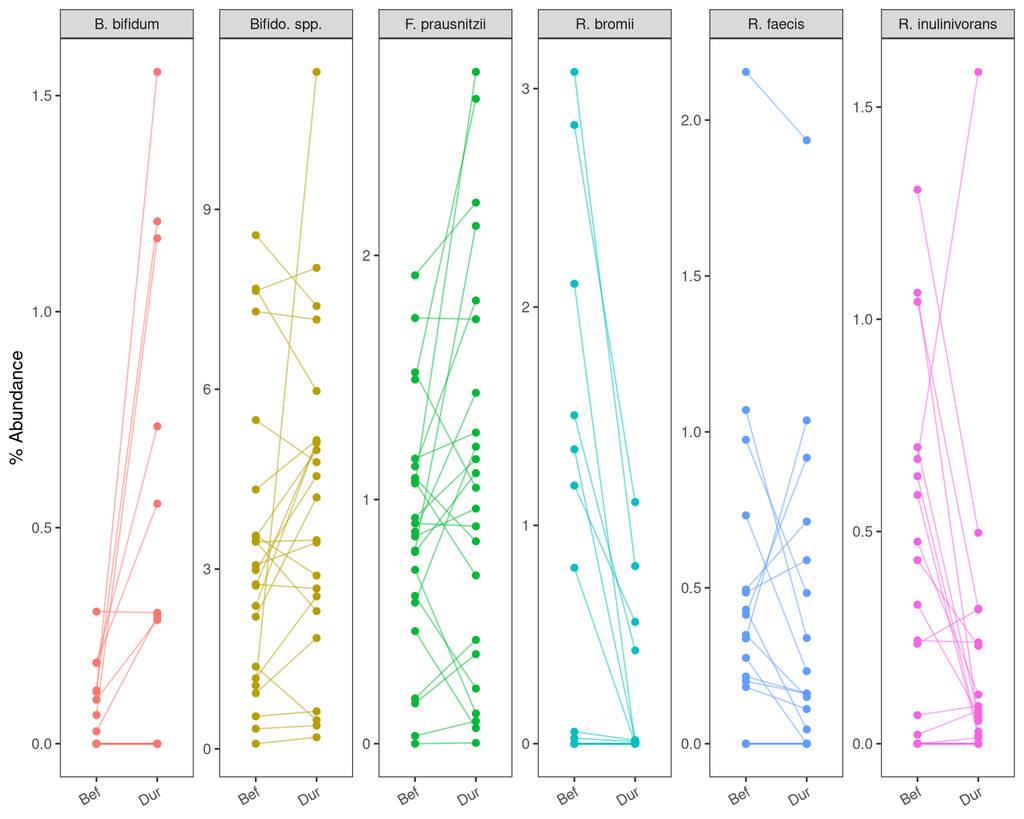

```r
# 1. Calculate mean abundance per subject
abundance_summary_dot <- all_targets_df %>%
  group_by(Species, Group, host_subject_id, status) %>%
  summarise(mean_abundance = mean(Abundance) * 100, .groups = "drop")

# 2. Reshape to wide (before / during in same row)
abundance_dot_wide <- abundance_summary_dot %>%
  pivot_wider(names_from = status, values_from = mean_abundance) %>%
  filter(!is.na(before) & !is.na(during))

# 3. Plot
dot_plot <- abundance_dot_wide %>%
  pivot_longer(cols = c(before, during), names_to = "timepoint", values_to = "percent_abundance") %>%
  ggplot(aes(x = timepoint, y = percent_abundance, group = host_subject_id)) +
  geom_point(aes(color = Species), size = 2) +
  geom_line(aes(color = Species), alpha = 0.5) +
  facet_wrap(~Species, scales = "free_y", nrow = 1) +
  scale_x_discrete(labels = c("before" = "Bef", "during" = "Dur")) +
  labs(x = NULL, y = "% Abundance") +
  theme_bw(base_size = 13) +
  theme(
    axis.text.x = element_text(angle = 30, hjust = 1, vjust = 1),
    legend.position = "none",
    panel.grid = element_blank()
  )

# 4. Display
dot_plot
```

# boxplot butyrate change

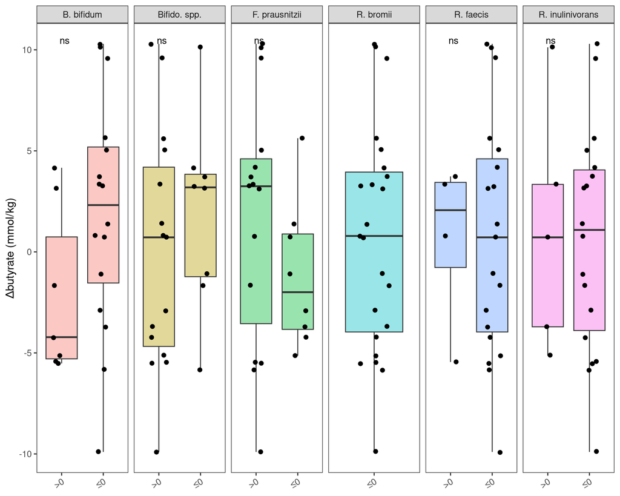

```r
# 2. Calculate Δbutyrate (during - before) per host_subject_id
butyrate_change_df_box <- all_targets_df %>%
  group_by(Species, Group, host_subject_id, status) %>%
  summarise(
    mean_butyrate = mean(Butyrate, na.rm = TRUE),
    mean_abundance = mean(Abundance),
    .groups = "drop"
  ) %>%
  pivot_wider(names_from = status, values_from = c(mean_butyrate, mean_abundance)) %>%
  filter(!is.na(mean_butyrate_before) & !is.na(mean_butyrate_during)) %>%
  mutate(
    delta_butyrate = mean_butyrate_during - mean_butyrate_before,
    delta_abundance = mean_abundance_during - mean_abundance_before,
    abundance_change_group = if_else(delta_abundance > 0, ">0", "≤0")  # split based on abundance change
  )

# 3. Plot
butyrate_boxplot <- butyrate_change_df_box %>%
  ggplot(aes(x = abundance_change_group, y = delta_butyrate, fill = Species)) +
  geom_boxplot(alpha = 0.4, outlier.shape = NA) +
  geom_jitter(width = 0.2, size = 2) +
  facet_wrap(~Species, scales = "free_x", nrow = 1) +
  stat_compare_means(
    aes(group = abundance_change_group),   # <--- force grouping
    method = "wilcox.test",
    paired = FALSE,
    label = "p.signif",
    hide.ns = FALSE        # <--- show even non-significant comparisons
  ) +
  labs(x = NULL, y = "Δbutyrate (mmol/kg)") +
  theme_bw(base_size = 13) +
  theme(
    axis.text.x = element_text(angle = 30, hjust = 1, vjust = 1),
    panel.grid = element_blank(),
    legend.position = "none"
  )

# 4. Display
butyrate_boxplot
```

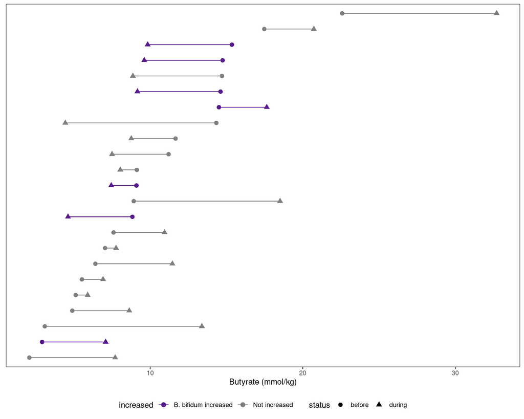

```r
# 1. Pivot butyrate data wider
butyrate_change_df <- ASV_df %>%
  select(host_subject_id, status, Butyrate) %>%
  filter(!is.na(Butyrate)) %>%
  group_by(host_subject_id, status) %>%
  summarise(Butyrate = mean(Butyrate), .groups = "drop") %>%
  pivot_wider(names_from = status, values_from = Butyrate)


# 2. Calculate if R. bromii (ASV_0070) increased
b_bifidum_changes <- ASV_df %>%
  filter(ASV == "ASV_0089") %>%
  group_by(host_subject_id, status) %>%    # average per subject per status
  summarise(Abundance = mean(Abundance), .groups = "drop") %>%
  pivot_wider(names_from = status, values_from = Abundance) %>%
  mutate(increased = if_else(during > before, "B. bifidum increased", "Not increased"))

# 3. Merge classification into butyrate data
butyrate_change_df <- butyrate_change_df %>%
  filter(!is.na(before) & !is.na(during)) %>%
  arrange(before) %>%
  mutate(subject_order = factor(host_subject_id, levels = host_subject_id))

# 4. Arrange by initial butyrate
butyrate_change_df <- butyrate_change_df %>%
  arrange(before) %>%
  mutate(subject_order = factor(host_subject_id, levels = host_subject_id))

# 5. Merge the "increased" classification into butyrate data
butyrate_change_df <- butyrate_change_df %>%
  left_join(b_bifidum_changes %>% select(host_subject_id, increased), by = "host_subject_id")

# 6. create long for status difference
#pivot for shape
butyrate_long <- butyrate_change_df %>%
  pivot_longer(cols = c(before, during),
               names_to = "status",
               values_to = "butyrate")

# 6. Create the Plot

butyrate_dotplot <- butyrate_long %>%
  ggplot(aes(x = butyrate, y = subject_order, group = host_subject_id)) +
  geom_line(aes(color = increased), size = 0.5) +
  geom_point(aes(shape = status, color = increased), size = 2.5, fill = "white") +
  scale_shape_manual(values = c("before" = 16, "during" = 17)) +  # 16 = circle, 17 = triangle
  scale_color_manual(values = c("B. bifidum increased" = "purple4", "Not increased" = "gray50")) +
  theme_bw() +
  labs(x = "Butyrate (mmol/kg)", y = NULL) +
  theme(
    legend.position = "bottom",
    panel.grid = element_blank(),
    axis.text.y = element_blank(),
    axis.ticks.y = element_blank()
  )

# Show plot
butyrate_dotplot
```

# Combine the plots to replicate the last in the paper

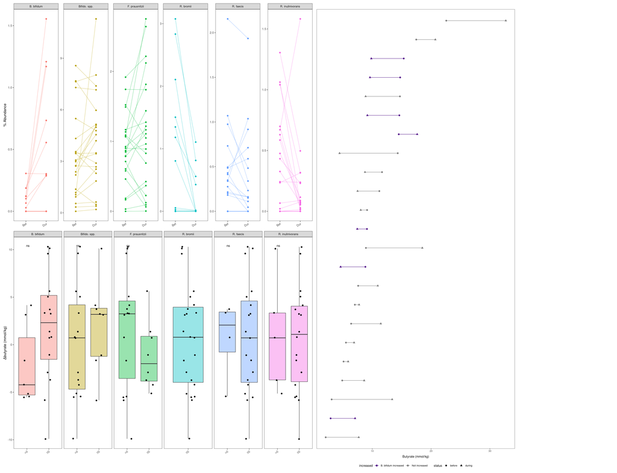

```r
left_part <- dot_plot / butyrate_boxplot  # Both use Species
final_combined_plot <- left_part | butyrate_dotplot +
  plot_layout(widths = c(2, 1)) +
  plot_annotation(tag_levels = "A")

# Show it
final_combined_plot
```

INTERPRETATION #6: Were the most abundant ASVs in your dataset represented in your ASV-level plots? If not, please go back and plot them specifically. (Hint: Remember that we ordered our ASV names by abundance across the entire dataset. Therefore, ASV_0001 will be the most abundant, ASV_0007 will be the 7th most abundant and so on.)

INTERPRETATION #7: Please make some plots at the ASV level as it relates to your scientific question. Were there any ASVs that were especially related to trends that you saw? Did a specific phylogenetic group all show the same trends (e.g. like the Actinomycetota ASVs above)? Or did the ASVs have various, likely niche-specific responses (similar to the Cyanobacteriota above)??

There were a lot more niche specific responses, I tried to look into the known primary degraders of fermentable fiber and butyrate producers, the degraders did have a response, the secondary butyrate producers dont seem to have a strong response to the treatment but this could be further explored with different graphs that I can replicate from the original paper.

INTERPRETATION #8: Now, do a quick literature or google search and look back in the paper that you may be replicating (if applicable). Does your ASV-level changes represent something that is currently known? Or is this a novel result? What did you learn about this ASV or a group of ASVs in your dataset?

They represent the degraders of fermentable fiber (inulin in this case) and butyrate producers, they are expected, what is unexpected is that ASVs not related to fermentable fiber had a in some cases even a stronger relationship to status than the degraders, but this could be caused by host differences.